# Determining the Correlations between Storm Event Type and Impacts to Population Health and Economic Consequence

Ryan Yancey

February 2021

# Synopsis

The purpose of this markdown is to document the start-to-finish analysis of NOAA’s storm data from 1950 to 2011. First, we will ensure that our directory structure is set up correctly, with the correct files downloaded from URLs and in the correct directory. Then, we will begin the long and laborious process of tidying the messy data into something much more pliable for our analysis. Since there is a discrepancy between pre-1993 and post-1993 cataloging styles, we will segment our set before using regex and approximate matching to clean up the messiest part of the data: Event Types. We’ll see that the fatalities and injuries data is already logged correctly, so no further processing will be required. Then, we will clean up the property and crop damage variables, as they are split up the number and the suffix (a letter to denote the multiplier of the number). Finally, after all the data is tidied up to our specification, we will answer two core questions:

1. Across the United States, which types of events are most harmful with respect to population health?
2. Across the United States, which types of events have the greatest economic consequences?

Let’s get started.

# Data Processing

## House-keeping

```r
library("dplyr")
library("R.utils")
library("stringr")
library("stringdist")
library("lubridate")
library("ggplot2")
library("reshape2")
```

```r
# create data directory
if (!dir.exists("data")) {
        dir.create("data")
}
```

Note: the storm events file was self-generated and it is available [here](https://raw.githubusercontent.com/ryancey1/datascience-coursera/main/4-reproducible-research/week4/data/events.txt). The data were generated from section **2.1.1 - Storm Data Event Table** in the [StormData-Documentation](https://d396qusza40orc.cloudfront.net/repdata%2Fpeer2_doc%2Fpd01016005curr.pdf) PDF file.

```r
# data file
download.file(url = "https://d396qusza40orc.cloudfront.net/repdata%2Fdata%2FStormData.csv.bz2",
              destfile = "data/repdata-data-StormData.csv.bz2")

# documentation file
download.file(url = "https://d396qusza40orc.cloudfront.net/repdata%2Fpeer2_doc%2Fpd01016005curr.pdf",
              destfile = "StormData-Documentation.pdf")

# storm events file -- produced from section 2.1.1 (page 6 of PDF)
download.file(url = "https://raw.githubusercontent.com/ryancey1/datascience-coursera/main/4-reproducible-research/week4/data/events.txt",
              destfile = "data/events.txt")
```

```r
# read in stormData and eventTypes tables
stormData <- read.csv("data/repdata-data-StormData.csv.bz2")
eventTypes <- read.delim("data/events.txt")
```

## Tidying the data

### Observing our raw `stormData`

First things first, we should quickly look at the structure of the raw data, as well as the head/tail of the loaded table. This will help us to get a feel of the data we want to process.

```r
head(stormData)
```

```
##   STATE__           BGN_DATE BGN_TIME TIME_ZONE COUNTY COUNTYNAME STATE  EVTYPE
## 1       1  4/18/1950 0:00:00     0130       CST     97     MOBILE    AL TORNADO
## 2       1  4/18/1950 0:00:00     0145       CST      3    BALDWIN    AL TORNADO
## 3       1  2/20/1951 0:00:00     1600       CST     57    FAYETTE    AL TORNADO
## 4       1   6/8/1951 0:00:00     0900       CST     89    MADISON    AL TORNADO
## 5       1 11/15/1951 0:00:00     1500       CST     43    CULLMAN    AL TORNADO
## 6       1 11/15/1951 0:00:00     2000       CST     77 LAUDERDALE    AL TORNADO
##   BGN_RANGE BGN_AZI BGN_LOCATI END_DATE END_TIME COUNTY_END COUNTYENDN
## 1         0                                               0         NA
## 2         0                                               0         NA
## 3         0                                               0         NA
## 4         0                                               0         NA
## 5         0                                               0         NA
## 6         0                                               0         NA
##   END_RANGE END_AZI END_LOCATI LENGTH WIDTH F MAG FATALITIES INJURIES PROPDMG
```

[output cut: 20 more lines]

```r
tail(stormData)
```

```
##        STATE__           BGN_DATE    BGN_TIME TIME_ZONE COUNTY
## 902292      47 11/28/2011 0:00:00 03:00:00 PM       CST     21
## 902293      56 11/30/2011 0:00:00 10:30:00 PM       MST      7
## 902294      30 11/10/2011 0:00:00 02:48:00 PM       MST      9
## 902295       2  11/8/2011 0:00:00 02:58:00 PM       AKS    213
## 902296       2  11/9/2011 0:00:00 10:21:00 AM       AKS    202
## 902297       1 11/28/2011 0:00:00 08:00:00 PM       CST      6
##                                  COUNTYNAME STATE         EVTYPE BGN_RANGE
## 902292 TNZ001>004 - 019>021 - 048>055 - 088    TN WINTER WEATHER         0
## 902293                         WYZ007 - 017    WY      HIGH WIND         0
## 902294                         MTZ009 - 010    MT      HIGH WIND         0
## 902295                               AKZ213    AK      HIGH WIND         0
## 902296                               AKZ202    AK       BLIZZARD         0
## 902297                               ALZ006    AL     HEAVY SNOW         0
##        BGN_AZI BGN_LOCATI           END_DATE    END_TIME COUNTY_END COUNTYENDN
```

[output cut: 48 more lines]

```r
str(stormData)
```

```
## 'data.frame':    902297 obs. of  37 variables:
##  $ STATE__   : num  1 1 1 1 1 1 1 1 1 1 ...
##  $ BGN_DATE  : chr  "4/18/1950 0:00:00" "4/18/1950 0:00:00" "2/20/1951 0:00:00" "6/8/1951 0:00:00" ...
##  $ BGN_TIME  : chr  "0130" "0145" "1600" "0900" ...
##  $ TIME_ZONE : chr  "CST" "CST" "CST" "CST" ...
##  $ COUNTY    : num  97 3 57 89 43 77 9 123 125 57 ...
##  $ COUNTYNAME: chr  "MOBILE" "BALDWIN" "FAYETTE" "MADISON" ...
##  $ STATE     : chr  "AL" "AL" "AL" "AL" ...
##  $ EVTYPE    : chr  "TORNADO" "TORNADO" "TORNADO" "TORNADO" ...
##  $ BGN_RANGE : num  0 0 0 0 0 0 0 0 0 0 ...
##  $ BGN_AZI   : chr  "" "" "" "" ...
##  $ BGN_LOCATI: chr  "" "" "" "" ...
##  $ END_DATE  : chr  "" "" "" "" ...
##  $ END_TIME  : chr  "" "" "" "" ...
##  $ COUNTY_END: num  0 0 0 0 0 0 0 0 0 0 ...
```

[output cut: 23 more lines]

```r
summary(stormData)
```

```
##     STATE__       BGN_DATE           BGN_TIME          TIME_ZONE
##  Min.   : 1.0   Length:902297      Length:902297      Length:902297
##  1st Qu.:19.0   Class :character   Class :character   Class :character
##  Median :30.0   Mode  :character   Mode  :character   Mode  :character
##  Mean   :31.2
##  3rd Qu.:45.0
##  Max.   :95.0
##
##      COUNTY       COUNTYNAME           STATE              EVTYPE
##  Min.   :  0.0   Length:902297      Length:902297      Length:902297
##  1st Qu.: 31.0   Class :character   Class :character   Class :character
##  Median : 75.0   Mode  :character   Mode  :character   Mode  :character
##  Mean   :100.6
##  3rd Qu.:131.0
##  Max.   :873.0
##
##    BGN_RANGE          BGN_AZI           BGN_LOCATI          END_DATE
##  Min.   :   0.000   Length:902297      Length:902297      Length:902297
##  1st Qu.:   0.000   Class :character   Class :character   Class :character
##  Median :   0.000   Mode  :character   Mode  :character   Mode  :character
##  Mean   :   1.484
##  3rd Qu.:   1.000
##  Max.   :3749.000
##
##    END_TIME           COUNTY_END COUNTYENDN       END_RANGE
##  Length:902297      Min.   :0    Mode:logical   Min.   :  0.0000
##  Class :character   1st Qu.:0    NA's:902297    1st Qu.:  0.0000
##  Mode  :character   Median :0                   Median :  0.0000
##                     Mean   :0                   Mean   :  0.9862
##                     3rd Qu.:0                   3rd Qu.:  0.0000
##                     Max.   :0                   Max.   :925.0000
##
##    END_AZI           END_LOCATI            LENGTH              WIDTH
##  Length:902297      Length:902297      Min.   :   0.0000   Min.   :   0.000
##  Class :character   Class :character   1st Qu.:   0.0000   1st Qu.:   0.000
##  Mode  :character   Mode  :character   Median :   0.0000   Median :   0.000
##                                        Mean   :   0.2301   Mean   :   7.503
##                                        3rd Qu.:   0.0000   3rd Qu.:   0.000
##                                        Max.   :2315.0000   Max.   :4400.000
##
```

[output cut: 25 more lines]

```
##  Min.   :-14451   Min.   :   0   Min.   :-14455   Length:902297
##  1st Qu.:  7247   1st Qu.:   0   1st Qu.:     0   Class :character
##  Median :  8707   Median :   0   Median :     0   Mode  :character
##  Mean   :  6940   Mean   :1452   Mean   :  3509
##  3rd Qu.:  9605   3rd Qu.:3549   3rd Qu.:  8735
##  Max.   : 17124   Max.   :9706   Max.   :106220
##                   NA's   :40
##      REFNUM
##  Min.   :     1
##  1st Qu.:225575
##  Median :451149
##  Mean   :451149
##  3rd Qu.:676723
##  Max.   :902297
##
```

```r
head(eventTypes)
```

```
##                   EVTYPE Designator
## 1 Astronomical Low Tide           Z
## 2             Avalanche           Z
## 3              Blizzard           Z
## 4         Coastal Flood           Z
## 5       Cold/Wind Chill           Z
## 6           Debris Flow           C
```

### Select and reformat needed columns

Okay, there are *a lot* of columns we won’t need for this analysis. Let’s remove those unnecessary columns and then fix the column names to be more readable. We can do the same for the first column in the `eventTypes` data set.

```r
stormData2 <- stormData %>%
        select(
                BGN_DATE,
                BGN_TIME,
                EVTYPE,
                FATALITIES,
                INJURIES,
                PROPDMG,
                PROPDMGEXP,
                CROPDMG,
                CROPDMGEXP
        ) %>%
        rename(
                Date = BGN_DATE,
                Time = BGN_TIME,
                Event.Type = EVTYPE,
                Fatalities = FATALITIES,
                Injuries = INJURIES,
                Property.Damage = PROPDMG,
                Property.Damage.Exponent = PROPDMGEXP,
                Crop.Damage = CROPDMG,
                Crop.Damage.Exponent = CROPDMGEXP
        )

eventTypes <- eventTypes %>%
        rename(Event.Type = EVTYPE)

str(stormData2)
```

```
## 'data.frame':    902297 obs. of  9 variables:
##  $ Date                    : chr  "4/18/1950 0:00:00" "4/18/1950 0:00:00" "2/20/1951 0:00:00" "6/8/1951 0:00:00" ...
##  $ Time                    : chr  "0130" "0145" "1600" "0900" ...
##  $ Event.Type              : chr  "TORNADO" "TORNADO" "TORNADO" "TORNADO" ...
##  $ Fatalities              : num  0 0 0 0 0 0 0 0 1 0 ...
##  $ Injuries                : num  15 0 2 2 2 6 1 0 14 0 ...
##  $ Property.Damage         : num  25 2.5 25 2.5 2.5 2.5 2.5 2.5 25 25 ...
##  $ Property.Damage.Exponent: chr  "K" "K" "K" "K" ...
##  $ Crop.Damage             : num  0 0 0 0 0 0 0 0 0 0 ...
##  $ Crop.Damage.Exponent    : chr  "" "" "" "" ...
```

```r
str(eventTypes)
```

```
## 'data.frame':    48 obs. of  2 variables:
##  $ Event.Type: chr  "Astronomical Low Tide " "Avalanche " "Blizzard " "Coastal Flood " ...
##  $ Designator: chr  "Z" "Z" "Z" "Z" ...
```

Some initial notes to take:

1. We will need to format the `Date` column so that we can sort by dates
2. All of the number-based values we will compare across the US (`Fatalities`, `Injuries`, `Property.Damage`, and `Crop.Damage`) are already numeric primitives.
3. A massive overhaul of the `Event.Type` column is desperately needed (human error).
4. Both `Exponent` columns will need to go through an algorithm to change the multiplier placeholders (“H”, “K”, “M”, “B”) to their multiplier value (100, 1000, 1000000, 1000000000 respectively)

### Format the `Date` column

Now that we have columns and column names sorted out, we can begin to address some formatting issues within the entries themselves. For example, the `Date` column contains a “time” format (i.e 0:00:00) but that’s not necessary. We’ll go ahead and remove that format the entries with lubridate’s `mdy()` function. This ensures all the dates are in the YYYY-MM-DD format we will leverage later on.

```r
fixed.Dates <- stormData2$Date %>%
        str_split(pattern = " ", simplify = TRUE)
stormData2$Date <- mdy(fixed.Dates[,1])

str(stormData2)
```

[output not shown]

### Partition into pre/post-1993 data

Much better. Now, according to [NOAA documentation](https://www.ncdc.noaa.gov/stormevents/details.jsp?type=eventtype), prior to 1993, only “Tornado”, “Thunderstorm Wind”, and “Hail” events were recorded and kept part of the StormData documentation. After 1993, however, all 48 event types as indicated in `eventData` were utilized. So, it’s probably useful to partition our data into pre-1993 and post-1993 segments to avoid composition bias. We can do this by creating two subsets, one with a date up to and including December 31st, 1992, and all those thereafter.

```r
stormData.pre1993 <- stormData2 %>%
        filter(Date <= "1992-12-31") %>%
        arrange(Date, Time)
stormData.post1993 <- stormData2 %>%
        filter(Date >= "1993-01-01") %>%
        arrange(Date, Time)
```

Let’s take a look at the data sets we’ve generated.

```r
head(stormData.pre1993)
```

[output not shown]

```r
head(stormData.post1993)
```

[output not shown]

### Formatting event type data

First thing we need to do is ensure the event types are all in the same format. We will choose to have them as fully capitalized words. We’ll need to trim the white-space out, too. All of these can be accomplished with the `stringr` package. We can also avoid repetition by defining a function `string_fixer()` to handle all of this.

```r
# define a function to avoid repetition
string_fixer <- function(df) {
        df$Event.Type <- df$Event.Type %>%
                str_to_upper() %>%
                str_trim() %>%
                str_squish()
        return(df)
}

stormData.pre1993 <- string_fixer(stormData.pre1993)
stormData.post1993 <- string_fixer(stormData.post1993)
eventTypes <- string_fixer(eventTypes)
```

### Handling inconsistent `Event.Type` entries (the bulk of our analysis)

Since most of this data was generated by human-entry, there are a lot of errors and deviations. This whole section is devoted to fixing the Event.Type column, and subsequent sections will address the property and crop damage columns.

#### Pre-1993 Event Types

First, let’s focus on the pre-1993 data set. We should only expect three event types in this set (see the Partitioning section for the reason). How many of these entries already match the designated event types formatting? What are the unique entries?

```r
# let's vectorize the events list for ease of use
events <- eventTypes$Event.Type
# how many match this format?
table(stormData.pre1993$Event.Type %in% events)
```

```
##
## FALSE  TRUE
## 90963 96596
```

```r
# How many are unique event types?
length(unique(stormData.pre1993$Event.Type))
```

```
## [1] 3
```

```r
# what is the composition?
head(table(stormData.pre1993$Event.Type))
```

```
##
##      HAIL   TORNADO TSTM WIND
##     61832     34764     90963
```

Luckily enough, all of the mismatched entries are due to `THUNDERSTORM` being abbreviated as `TSTM`. We can fix this really easily and quickly and move on to the post-1993 data.

```r
stormData.pre1993$Event.Type <- gsub("TSTM", "THUNDERSTORM", stormData.pre1993$Event.Type)
table(stormData.pre1993$Event.Type %in% events)
```

```
##
##   TRUE
## 187559
```

#### Post-1993 Event Types

Now we can focus on the harder of the two: Post-1993 event types. Let’s quickly assess the work we need to do.

```r
# how many match the format?
table(stormData.post1993$Event.Type %in% events)
```

```
##
##  FALSE   TRUE
## 175979 538759
```

```r
# How many are unique event types?
length(unique(stormData.post1993$Event.Type))
```

```
## [1] 883
```

There are way more than 3 unique event types in the post-1993 data set. It’s not really useful to view how many fall into what category. Regardless, we’ve got a lot of work to do.

In the pre-1993 data, `THUNDERSTORM` was abbreviated as `TSTM`, in this data **136273** are abbreviated as such. Let’s fix that.

```r
stormData.post1993$Event.Type <- gsub("TSTM", "THUNDERSTORM", stormData.post1993$Event.Type)
table(stormData.post1993$Event.Type %in% events)
```

```
##
##  FALSE   TRUE
##  40821 673917
```

```r
still_unique <- unique(stormData.post1993$Event.Type[!(stormData.post1993$Event.Type %in% events)])
head(still_unique)
```

```
## [1] "ICE"            "FLOODING"       "HIGH WINDS"     "SNOW"
## [5] "FREEZING RAIN"  "FLASH FLOODING"
```

```r
length(still_unique)
```

```
## [1] 828
```

This makes sense, since we only corrected one word’s abbreviation. It would be uncharacteristic of this type of data for such a quick fix to take care of all the issues. Finally, let’s take care of the rest of the remaining entries. We’ll do this with a for-loop, but this algorithm is not very efficient so it’s not advised to do this on a large data set… (verging on $O(n^2)$ if you’re a fan of algorithm analysis).

First, let’s set vectorize the Event.Type column twice: one that remains unaltered, and another that goes through the algorithm.

```r
pre.alg <- stormData.post1993$Event.Type
post.alg <- stormData.post1993$Event.Type
```

This only serves to see how well the algorithm worked. Now let’s run the algorithm

```r
for (i in seq_along(events)) {

        rx <- str_sub(events[i], end = 3)
        found <- grep(rx, post.alg) # get indices of matches
        matches <- post.alg[found] # pull those values
        table <- events[grep(rx, events)] # pull the event names
        keys <- amatch(matches, table, method = "jw", maxDist = 0.3) # fuzzy match and store the keys

        # replace EVTYPE with cleaned value
        for (j in seq_along(keys)) {
                if (is.na(keys[j])) {
                        post.alg[found[j]] <- NA
                }
                else {
                        post.alg[found[j]] <- table[keys[j]]
                }
        }
}
```

The above algorithm performs the following steps:

1. Create a REGEX search by taking the correct event names and removing all but the first 3 characters. (i.e. `THUNDERSTORM WIND` becomes `THU`).
2. Grab the indices in the event types list of the values that match the regex with the `grep()` function.
3. Keep the values that match, as well as the event names that match.
4. Approximately match those values with the `amatch()` function set to the Jaro-Wilker distance metric and store those. *(Those that don’t meet the distance metric are replaced with NAs in the keys vector)*
5. For those that aren’t NAs, replace the original name with the matched name. All others should be replaced with NA (this will help later on).

Great. So how did the algorithm perform?

```r
summary(pre.alg %in% events)
```

```
##    Mode   FALSE    TRUE
## logical   40821  673917
```

```r
summary(post.alg %in% events)
```

```
##    Mode   FALSE    TRUE
## logical    9010  705728
```

Before the algorithm, 5.71% of the events did not match. The algorithm left us with only 1.26% not matching. In addition, only 0.82% were replaced with `NA` values. The algorithm itself wasn’t terribly efficient, but the result is good enough to omit the `NAs` now.

Now we can finally replace the column and omit those with `NAs`.

```r
stormData.post1993$Event.Type <- post.alg
stormData.post1993 <- stormData.post1993 %>%
        filter(!is.na(Event.Type)) %>%
        filter(Event.Type %in% events)

## verify that all the Event.Types are up to par
summary(stormData.post1993$Event.Type %in% events)
```

```
##    Mode    TRUE
## logical  705728
```

```r
summary(stormData.pre1993$Event.Type %in% events)
```

```
##    Mode    TRUE
## logical  187559
```

All of them are true, so our cleaning of this column is complete. Now we will append a marker to the end of the table and bind the two data frames.

```r
stormData.post1993$pre.post.1993 <- "After 1993"
stormData.pre1993$pre.post.1993 <- "Before 1993"

## replace the already existing stormData2 with the new, cleaner data.
stormData2 <- rbind(stormData.pre1993, stormData.post1993)
head(stormData2)
```

[output not shown]

### Handling the `Property.Damage` and `Crop.Damage` columns

The property damage and crop damage columns contain the first few digits of the text entry contained within each record, and the “Exponent” column contains the marker for the “place” of the data (i.e M for ‘million’, K for ‘thousand’, etc). What does the data look like as of yet in these columns?

```r
table(stormData2$Property.Damage.Exponent)
```

```
##
##             -      ?      +      0      1      2      3      4      5      6
## 459132      1      8      4    216     25     13      4      4     27      4
##      7      8      B      h      H      K      m      M
##      5      1     38      1      6 422570      7  11221
```

```r
table(stormData2$Crop.Damage.Exponent)
```

```
##
##             ?      0      2      B      k      K      m      M
## 610132      7     19      1      8     20 281144      1   1955
```

A large majority of these are blank, “K”, or “M”. Although the B isn’t a large majority, it stands for “Billions”, so we want to keep those values. We can remove all the others with single number values and punctuation and also convert the character dollar amount in the `Crop.Damage` and `Property.Damage` columns to a numeric primitive type.

```r
## Property damage cleaning
stormData2 <- stormData2[-(grep("[[:punct:]]|[0-9]", stormData2$Property.Damage.Exponent)), ]
stormData2$Property.Damage.Exponent <- str_to_upper(stormData2$Property.Damage.Exponent)

## Crop damage cleaning
stormData2 <- stormData2[-(grep("[[:punct:]]|[0-9]", stormData2$Crop.Damage.Exponent)), ]
stormData2$Crop.Damage.Exponent <- str_to_upper(stormData2$Crop.Damage.Exponent)

table(stormData2$Property.Damage.Exponent)
```

```
##
##             B      H      K      M
## 459126     38      7 422550  11227
```

```r
table(stormData2$Crop.Damage.Exponent)
```

```
##
##             B      K      M
## 609828      8 281158   1954
```

```r
summary(stormData2)
```

[output not shown]

Okay, so what do those blank entries mean?

```r
blank.prop <- stormData2[stormData2$Property.Damage.Exponent == "", ]
table(blank.prop$Property.Damage)
```

```
##
##      0      1      2      3      4      5      6      7      8      9     10
## 459055      4      7     16      7     11      5      3      2      3      7
##     20     35     75
##      4      1      1
```

```r
blank.crop <- stormData2[stormData2$Crop.Damage.Exponent == "", ]
table(blank.crop$Property.Damage)
```

```
##
##      0   0.01   0.02   0.03   0.04   0.05   0.06   0.07   0.08    0.1   0.11
## 466612    899     75   1604      3    542     24      3      2   1213     27
##   0.12   0.13   0.15   0.16   0.17    0.2   0.21   0.22   0.25    0.3   0.35
##      6      1     39      1      2    409      2      1   1779    195      6
##    0.4   0.45    0.5   0.51   0.55    0.6   0.65   0.66    0.7   0.75   0.76
##     77      2   4481      2      2     55      3      1     31    306     10
##   0.78    0.8   0.81   0.84   0.85   0.86    0.9   0.95   0.99      1   1.01
##      1     76      1      1     12      1     30      1      1   9084      3
##   1.02   1.03   1.04   1.05   1.06   1.07    1.1   1.11   1.13   1.14   1.15
##      3      2      3      9      4      2     53      2      5      2     13
##   1.16   1.18    1.2   1.24   1.25   1.26   1.27   1.28   1.29    1.3   1.32
##      1      1    101      3     50      3      1      3      2     36      2
##   1.33   1.34   1.35   1.37   1.38    1.4   1.41   1.43   1.45   1.46   1.47
##      1      1      2      2      1     32      1      2      2      2      2
```

[output cut: 166 more lines]

Now we can convert the dollar value from the abbreviated form to the long-form by replacing the letter-based abbreviation with their associated multiplier and the blank spaces with ones. The scheme is as follows:

- "" == 1
- “H” == 100
- “K” == 1000
- “M” == 1000000
- “B” == 1000000000

This scheme was adapted from a previous student’s work (see [here](https://rstudio-pubs-static.s3.amazonaws.com/58957_37b6723ee52b455990e149edde45e5b6.html)). Then, we will convert them to their numeric values and multiplying across the `Property.Damage` and `Property.Damage.Exponent` columns, as well as the `Crop.Damage` and `Crop.Damage.Exponent` columns to obtain their actual values.

```r
## replace letter-based abbreviations
stormData2$Property.Damage.Exponent <- stormData2$Property.Damage.Exponent %>%
        str_replace("[^KMBH]", "1") %>%
        str_replace("H", "100") %>%
        str_replace("K", "1000") %>%
        str_replace("M", "1000000") %>%
        str_replace("B", "1000000000") %>%
        as.numeric()

## replace letter-based abbreviations
stormData2$Crop.Damage.Exponent <- stormData2$Crop.Damage.Exponent %>%
        str_replace("[^KMB]", "1") %>%
        str_replace("K", "1000") %>%
        str_replace("M", "1000000") %>%
        str_replace("B", "1000000000") %>%
        as.numeric()

## multiply across the columns to calculate the total damage
stormData2$Property.Damage <- stormData2$Property.Damage * stormData2$Property.Damage.Exponent
stormData2$Crop.Damage <- stormData2$Crop.Damage * stormData2$Crop.Damage.Exponent
```

Now that we’ve finally got the property and crop damage columns formatted, we can move on to generating plots to summarize our data.

# Results

First, we will look at population health, then economic devastation.

## 1. Across the United States, which types of events are most harmful with respect to population health?

Which events constitute the top 10 in terms of public health devastation? To answer this, we will calculate the average of injuries and fatalities per event.

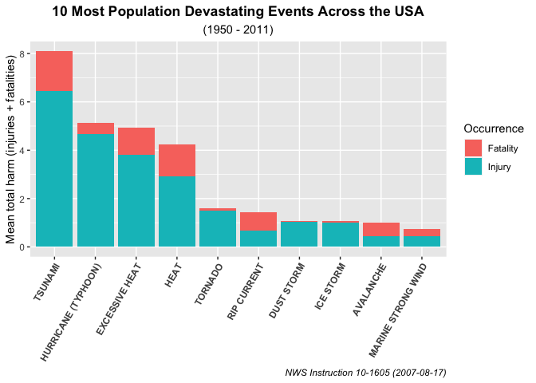

```r
## summarize health damage
stormData2.health.norm <- stormData2 %>%
        group_by(Event.Type) %>%
        summarize(count = n(),
                  Fatality = mean(Fatalities),
                  Injury = mean(Injuries),
                  TotalHarms = Fatality + Injury) %>%
        slice_max(order_by = TotalHarms, n = 10)

melted <- melt(stormData2.health.norm, id.vars = c("Event.Type", "count"), variable.name = "Occurrence")

ggplot(subset(melted, Occurrence != "TotalHarms"), aes(y = value, x = reorder(Event.Type, -value), fill = Occurrence)) +
        geom_col() +
        theme(axis.text.x=element_text(angle = 60, hjust = 1, face = "bold"),
              plot.title = element_text(hjust = 0.5, face = "bold"),
              plot.subtitle = element_text(hjust = 0.5),
              plot.caption = element_text(face = "italic")) +
        ylab("Mean total harm (injuries + fatalities)") +
        xlab(NULL) +
        labs(title = "10 Most Population Devastating Events Across the USA",
             subtitle = "(1950 - 2011)",
             caption = "NWS Instruction 10-1605 (2007-08-17)")
```

**Unsurprisingly, tsunamis and hurricanes cause the highest degree of health devastation due to their massive scale.**

## 2. Across the United States, which types of events have the greatest economic consequences?

Which events constitute the top 10 in terms of economic devastation? To answer this, we will separately calculate the average of property damage and crop damage per event.

### Property Damage

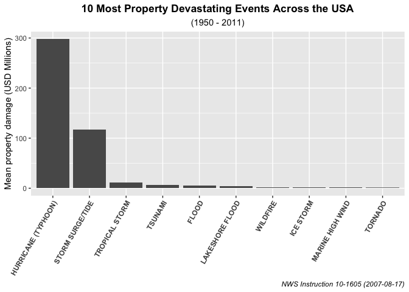

```r
## summarize property damage
stormData2.econ.norm <- stormData2 %>%
        group_by(Event.Type) %>%
        summarize(count = n(),
                  Prop.Dmg = sum(Property.Damage)/count) %>%
        slice_max(order_by = Prop.Dmg, n = 10)

ggplot(stormData2.econ.norm, aes(y = Prop.Dmg/1e6, x = reorder(Event.Type, -Prop.Dmg))) +
        geom_col() +
        theme(axis.text.x=element_text(angle = 60, hjust = 1, face = "bold"),
              plot.title = element_text(hjust = 0.5, face = "bold"),
              plot.subtitle = element_text(hjust = 0.5),
              plot.caption = element_text(face = "italic")) +
        ylab("Mean property damage (USD Millions)") +
        xlab(NULL) +
        labs(title = "10 Most Property Devastating Events Across the USA",
             subtitle = "(1950 - 2011)",
             caption = "NWS Instruction 10-1605 (2007-08-17)")
```

**Hurricanes, storm surges and other water-related weather events cause the greatest levels of property damage. This may be likely due to water-damage, and not just devastation.**

### Crop Damage

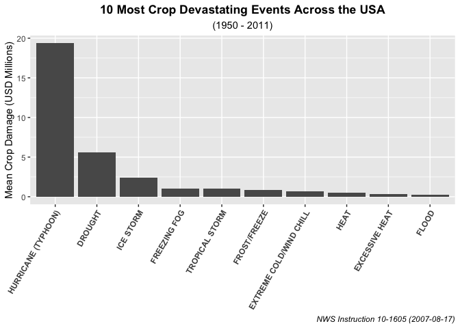

```r
## summarize crop damage
stormData2.econ.norm <- stormData2 %>%
        group_by(Event.Type) %>%
        summarize(count = n(),
                  Crop.Dmg = sum(Crop.Damage)/count) %>%
        slice_max(order_by = Crop.Dmg, n = 10)

ggplot(stormData2.econ.norm, aes(y = Crop.Dmg/1e6, x = reorder(Event.Type, -Crop.Dmg))) +
        geom_col() +
        theme(axis.text.x=element_text(angle = 60, hjust = 1, face = "bold"),
              plot.title = element_text(hjust = 0.5, face = "bold"),
              plot.subtitle = element_text(hjust = 0.5),
              plot.caption = element_text(face = "italic")) +
        ylab("Mean Crop Damage (USD Millions)") +
        xlab(NULL) +
        labs(title = "10 Most Crop Devastating Events Across the USA",
             subtitle = "(1950 - 2011)",
             caption = "NWS Instruction 10-1605 (2007-08-17)")
```

**Unsurprisingly, droughts are the second greatest cause of crop damage in the United States, and hurricanes/typhoons (with their high wind) cause the most damage.**